# THSS 730 - Lab 1

## Histograms

`ggplot2` plots just about anything. To make a histogram, we just use `geom_histogram()` and specify which variable we want to examine:

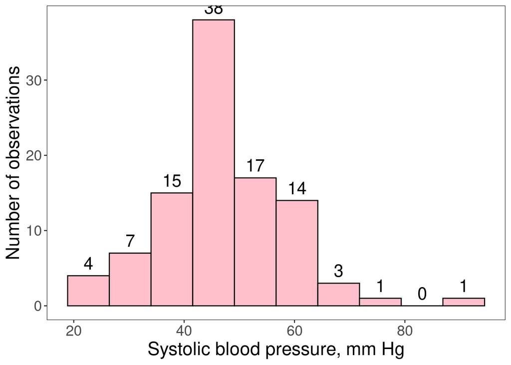

```r
breaks <- seq(20, 100, length.out = 10)

ggplot(data_birth_weight) +
  aes(x = sbp) +
  labs(x = "Systolic blood pressure, mm Hg",
       y = "Number of observations") +
  geom_histogram(bins = 10, color = 'black', fill = 'pink') +
  theme_bw() +
  theme(panel.grid = element_blank(),
        text = element_text(size = 18))  +
  stat_bin(
    aes(y = after_stat(count), label = after_stat(count)),
    bins = 10,
    geom = "text",
    size = 6,
    vjust = -1/2
  )
```

## Boxplots

For boxplots, we’ll use the `geom_boxplot()` function. Here, we need to be careful about the *type* of variable that `sex` currently is. As you can see, if we try to make one boxplot for boys and one for girls with the current `data_birth_weight`, we get this:

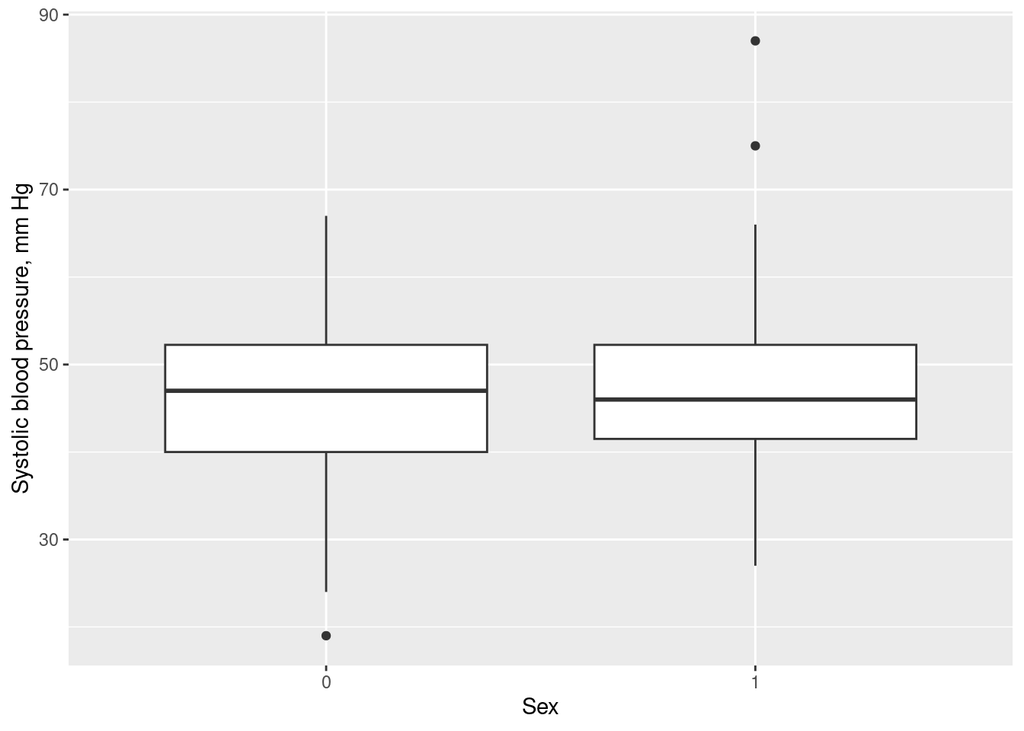

```r
ggplot(data_birth_weight) +
  aes(x = factor(sex), y = sbp) +
  labs(x = "Sex",
       y = "Systolic blood pressure, mm Hg") +
  geom_boxplot()
```

```r
data_birth_weight$sex <- factor(data_birth_weight$sex,
                                levels = c(0, 1),
                                labels = c("Girl", "Boy"))
```

Now,

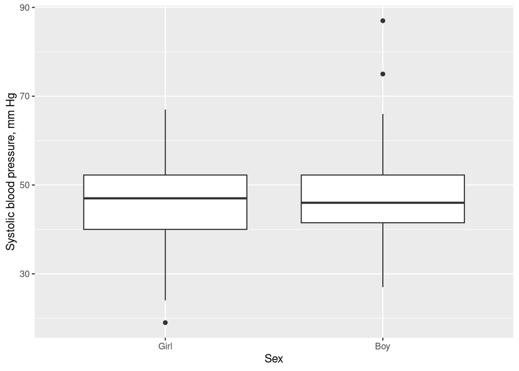

```r
ggplot(data_birth_weight) +
  aes(x = sex, y = sbp) +
  labs(x = "Sex",
       y = "Systolic blood pressure, mm Hg") +
  geom_boxplot()
```